# Spam or Not?

### 3. Validation and Explication

- To validate generated tree, I use the printcp and plotcp functions. “CP” stands for Complexity Parameter of the tree. The value of cp should be least, so that the cross-validated error rate is minimum. Plotcp() provides a graphical representation to the cross validated error summary. The cp values are plotted against the geometric mean to depict the deviation until the minimum value is reached.

```r
printcp(spam_tree)
```

```
##
## Classification tree:
## rpart(formula = spam_or_not ~ ., data = traindata, control = rpart.control(minsplit = 30))
##
## Variables actually used in tree construction:
## [1] V16 V25 V52 V53 V57 V7
##
## Root node error: 1605/4101 = 0.39137
##
## n= 4101
##
##         CP nsplit rel error  xerror     xstd
## 1 0.481620      0   1.00000 1.00000 0.019473
## 2 0.143925      1   0.51838 0.54206 0.016312
## 3 0.049221      2   0.37445 0.41620 0.014733
## 4 0.037383      3   0.32523 0.34455 0.013628
## 5 0.030530      4   0.28785 0.32586 0.013309
## 6 0.011838      5   0.25732 0.29034 0.012663
## 7 0.010000      6   0.24548 0.27227 0.012311
```

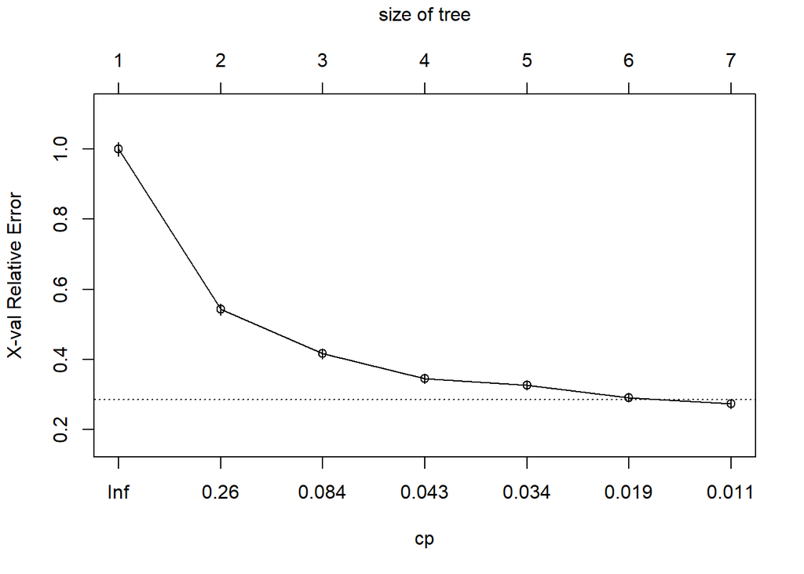

```r
plotcp(spam_tree)
```

- Hence I want the cp value (with a simpler tree) that minimizes the xerror. So, find best CP and generate **pruned classification tree** to move on.
- (I know, I don’t need pruning my tree actually but i should be able to try this model for bigger or smaller version of this dataset.**(For Compability, Reproducibility and my honour … )**

```r
bestcp <- spam_tree$cptable[which.min(spam_tree$cptable[,"xerror"]),"CP"]
pruned_tree <- prune(spam_tree, cp = bestcp)
printcp(pruned_tree)
```

```
##
## Classification tree:
## rpart(formula = spam_or_not ~ ., data = traindata, control = rpart.control(minsplit = 30))
##
## Variables actually used in tree construction:
## [1] V16 V25 V52 V53 V57 V7
##
## Root node error: 1605/4101 = 0.39137
##
## n= 4101
##
##         CP nsplit rel error  xerror     xstd
## 1 0.481620      0   1.00000 1.00000 0.019473
## 2 0.143925      1   0.51838 0.54206 0.016312
## 3 0.049221      2   0.37445 0.41620 0.014733
## 4 0.037383      3   0.32523 0.34455 0.013628
## 5 0.030530      4   0.28785 0.32586 0.013309
## 6 0.011838      5   0.25732 0.29034 0.012663
## 7 0.010000      6   0.24548 0.27227 0.012311
```

```r
#plotcp(pruned_tree)
```

```r
#confision matrices
conf.matrix <- table(traindata$spam_or_not, predict(pruned_tree,type="class"))
rownames(conf.matrix) <- paste("Actual", rownames(conf.matrix), sep = ":")
colnames(conf.matrix) <- paste("Pred", colnames(conf.matrix), sep = ":")
print(conf.matrix)
```

```
##
##            Pred:0 Pred:1
##   Actual:0   2381    115
##   Actual:1    279   1326
```

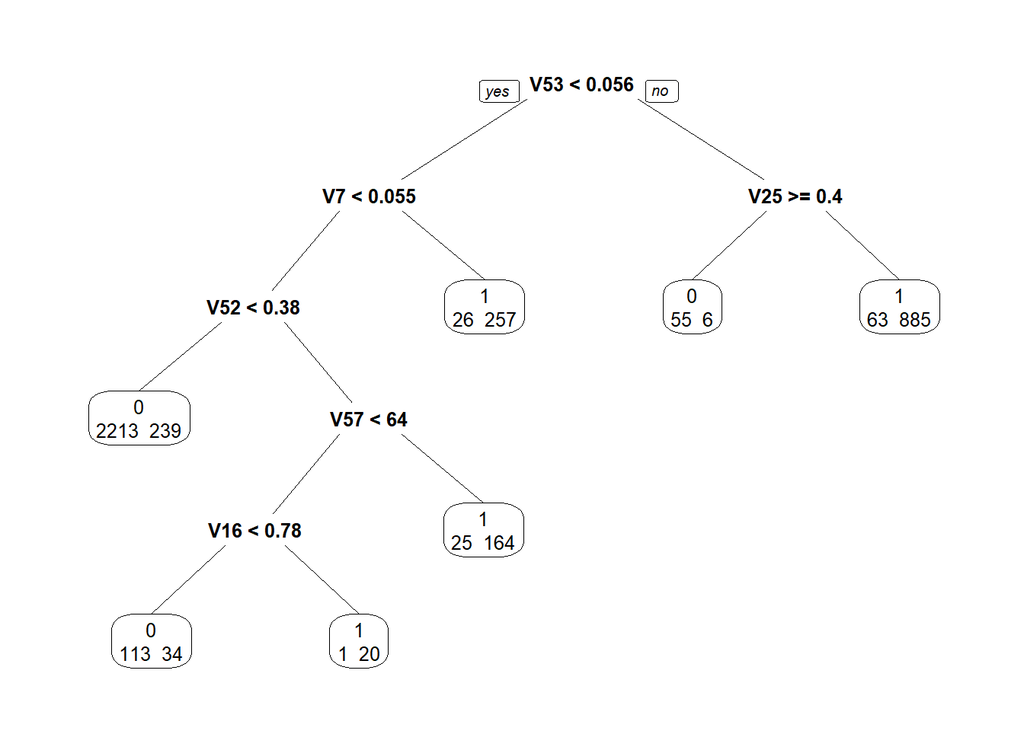

```r
#plot to understand.
# faclen = 0 means to use full names of the factor labels
# extra = 1 adds number of observations at each node; equivalent to using use.n = TRUE in plot.rpart
prp(pruned_tree, faclen = 0, cex = 0.8, extra = 1)
```

#### References

- [Creating, Validating and Pruning Decision Tree in R](https://www.edureka.co/blog/implementation-of-decision-tree/)
- [CART with rpart](https://rstudio-pubs-static.s3.amazonaws.com/27179_e64f0de316fc4f169d6ca300f18ee2aa.html)
- [Statistical Models in R:Part 2](https://mef-bda503.github.io/files/intro_to_ml_2.pdf) -[Plot prp](http://www.milbo.org/rpart-plot/prp.pdf)